[figure not shown]

# CoRe Survey Results

## Spring 2026

# About the Report

A survey was administered to the students of faculty participating in the Course Redesign for Equity (CoRe) Program to assess student perceptions of courses and instructor at multiple time points: before faculty started the CoRe program (pre) and after faculty completed the CoRe program (post). This report presents an analysis of the survey results, comparing responses between the pre and post groups to identify any significant changes in student perceptions.

- **Instructor Trust**: Instructor trust measures the multi-dimensional nature of instructor-student trust, including understanding, acceptance, and care.
- **Instructor Growth Mindset**: This construct assesses the perceived instructor mindset regarding student intelligence, specifically whether students feel their instructor views their academic potential as predetermined (fixed mindset) or malleable (growth mindset).
- **Course Organization**: Course evaluation measures how well-organized and clearly structured the course is perceived to be by students.
- **Relational Validation and Sense of Belonging**: A set of items was analyzed using exploratory factor analysis (EFA) to identify underlying dimensions of student perceptions, resulting in two factors: relational validation (e.g., feeling respected by the instructor) and sense of belonging (e.g., feeling like they belong in the course).

## About the Analyses

The survey analyses compared students’ scores on instructor and course experiences before faculty started the CoRe program (pre) and after faculty completed the CoRe program (post).

The initial plot(s) in each section visualizes the mean scores for both the overall construct and the individual items, comparing pre and post groups.

The next plot(s) in each section breaks down the percentage of students who agreed or disagreed with the statements. This gives additional context to the mean scores.

# Survey Results Pre- and Post-CoRe

## Instructor Trust

The survey utilizes a framework developed by Cavanaugh et al. (2018) to measure the multi-dimensional nature of instructor-student trust. Specifically, the survey operationalizes three primary dimensions of trust: understanding, acceptance, and care.

**Figure 1:** Instructor Trust: Pre-CoRe vs Post-CoRe Means

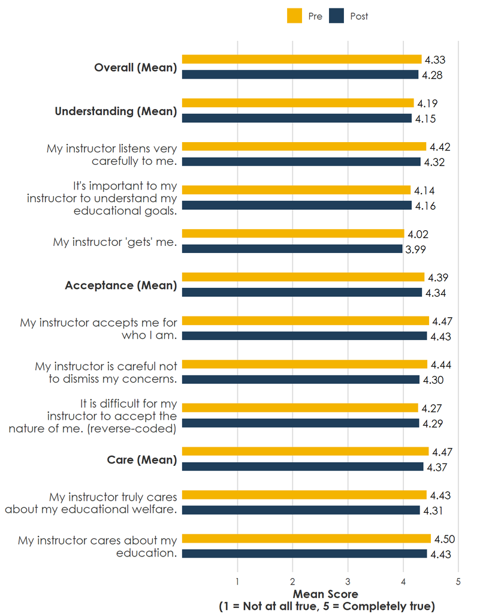

Figure 1

**Figure 2:** Instructor Trust: Pre-CoRe vs Post-CoRe Likert Scale

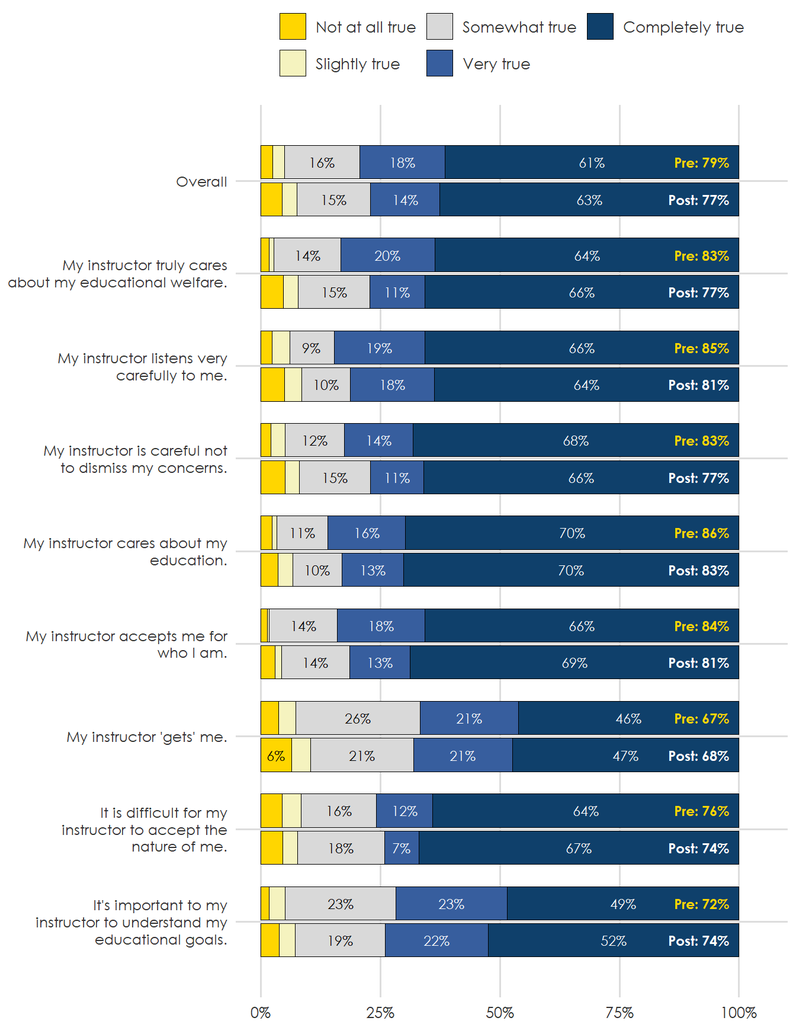

Figure 2

## Instructor Growth Mindset

This subset of questions measures the perceived instructor mindset regarding student intelligence, grounded in the research on implicit theories of intelligence (Dweck, 1999). These three items specifically measure whether students feel their instructor views their academic potential as predetermined. High scores on these items indicate that students perceive a “growth mindset” environment.

Mean scores were nearly identical across groups, with pre respondents reporting a mean of 5.21 and post respondents reporting a mean of 5.17, a difference of −0.04 points. This difference was not statistically significant, indicating that any observed variation is small relative to overall variability in responses.

**Similar to perceptions of instructor trust, students were slightly less likely to believe that the instructors had a growth mindset. However, these differences are minimal and not significant.**

**Figure 3:** Instructor Growth Mindset: Pre-CoRe vs Post-CoRe Means

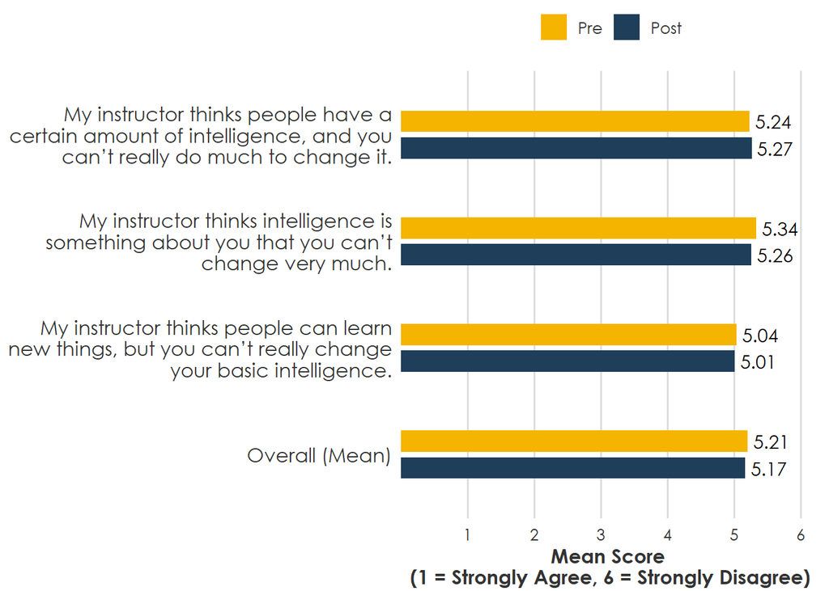

Figure 3

**Figure 4:** Instructor Growth Mindset: Pre-CoRe vs Post-CoRe Likert Scale

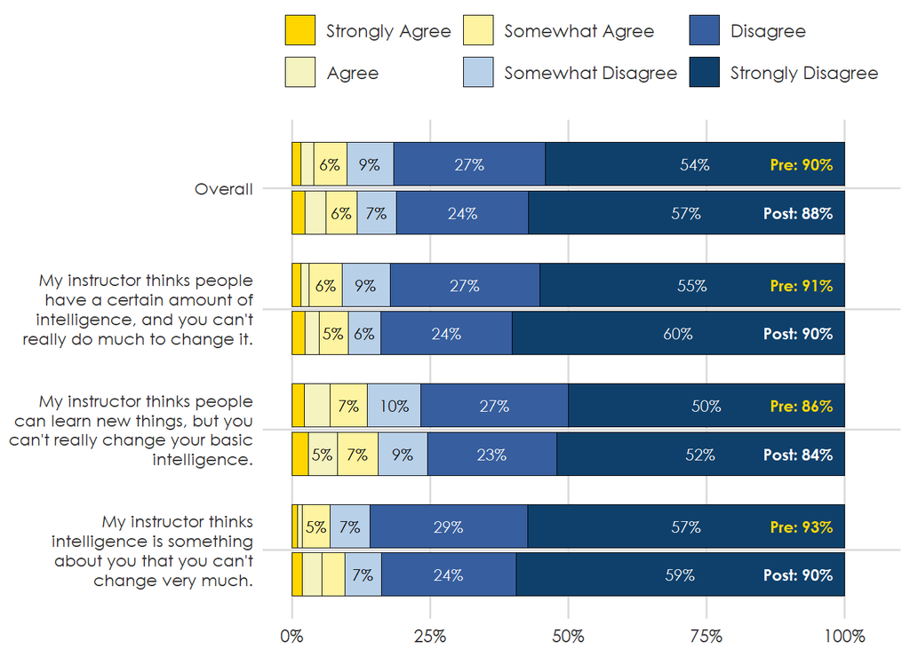

Figure 4

## Course Organization

The survey also investigated how the course was organized. Across all items, mean scores were high in both groups, indicating generally strong agreement that courses were clearly structured. Post-CoRe respondents reported slightly higher scores than pre-CoRe respondents on every item, but the differences were minimal. The overall mean increased from 4.39 to 4.44, a difference of 0.05 points.

**Overall, these results suggest that perceptions of course organization and clarity were already high prior to CoRe and remained consistently high afterward, with modest but not significant improvements across items. Students were more likely to indicate post-CoRe that the class is more organized.**

**Figure 5:** Course Organization: Pre-CoRe vs Post-CoRe Means

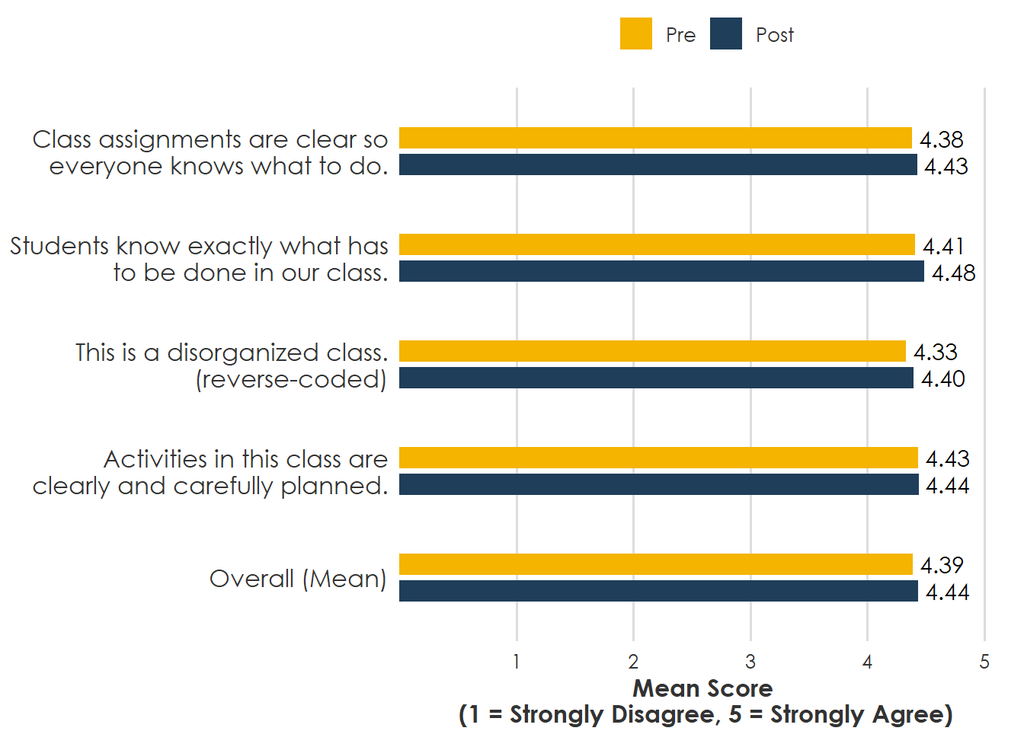

Figure 5

**Figure 6:** Course Organization: Pre-CoRe vs Post-CoRe Likert Scale

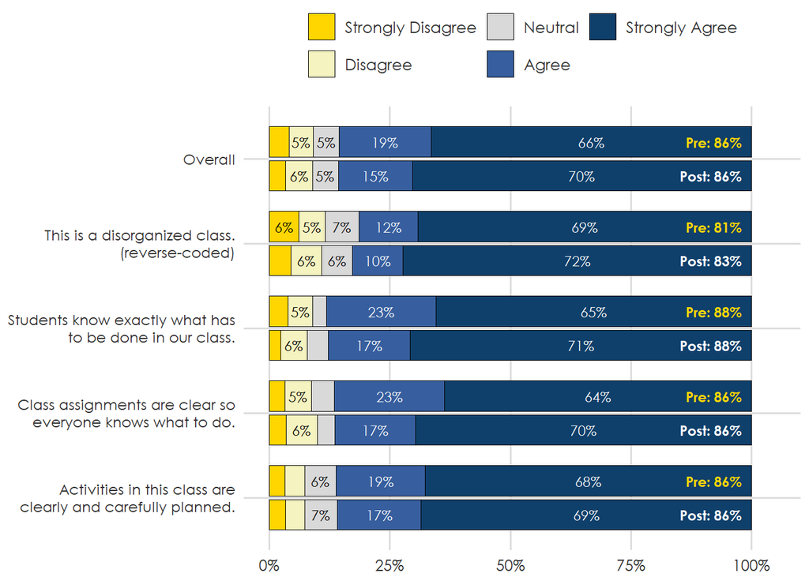

Figure 6

## Relational Validation and Sense of Belonging

**Overall, the results suggest that students’s experiences of relational validation and belonging were high before instructors participated in CoRe, with a slight and not significant decrease after instructors participated in CoRe.**

**Figure 7:** Relational Validation and Sense of Belonging: Pre-CoRe vs Post-CoRe Means

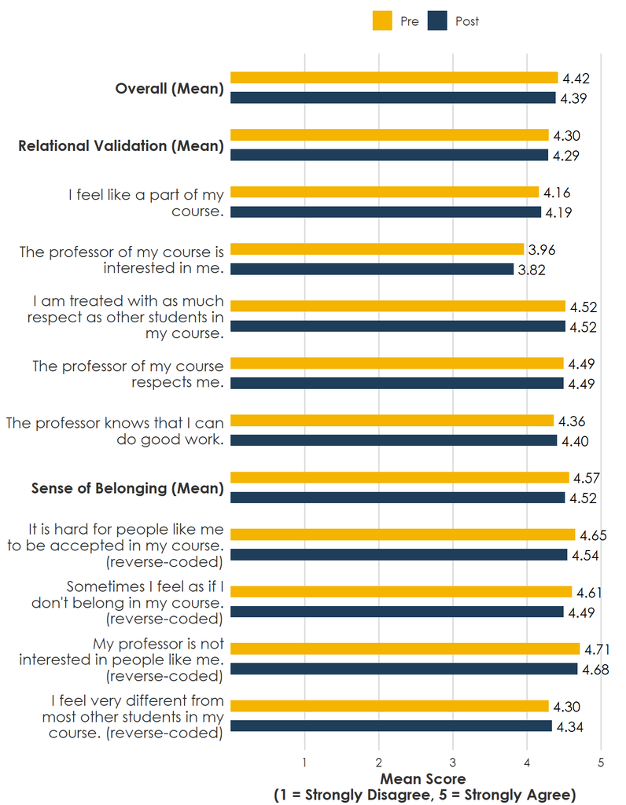

Figure 7

**Figure 8:** Relational Validation: Pre-CoRe vs Post-CoRe Likert Scale

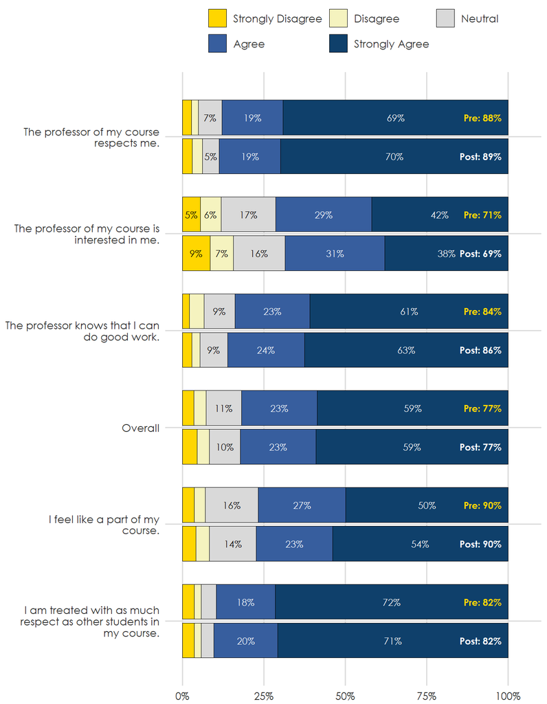

Figure 8

**Figure 9:** Sense of Belonging: Pre-CoRe vs Post-CoRe Likert Scale

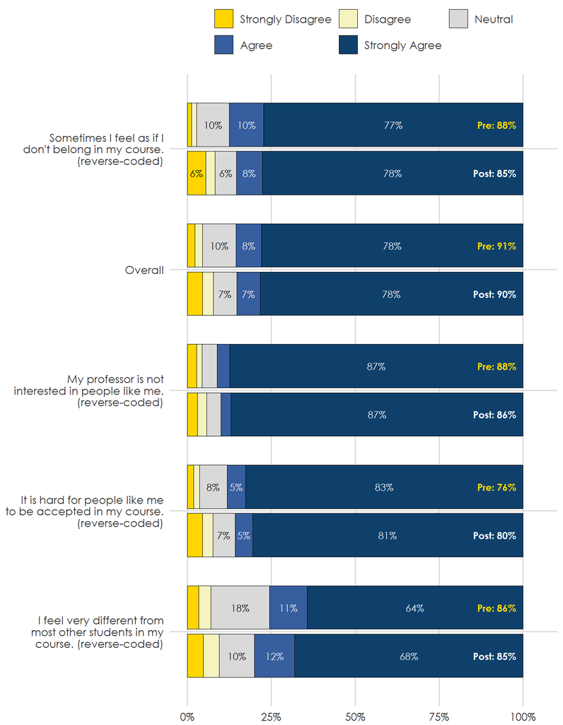

Figure 9

# Differences by Demographics

Even though no overall differences were found, results across different student groups were also examined to see if any patterns emerged, specifically by race/ethnicity, college generational status, gender, and financial aid status. This helps provide more context by showing how experiences may differ across groups, even when overall results appear similar. These findings are descriptive and meant to highlight potential differences, not to draw conclusions about cause.

In this section of the report, results across different student groups were also examined to see if any patterns emerged, specifically by race/ethnicity, college generational status, gender, and financial aid status.

**To interpret these findings, consider the direction (i.e., right or left of the line) and magnitude of the change represented in the horizontal bars (i.e., length of bar). Each bar visualizes the difference in mean scores, between the start of the term (pre-CoRe) and the end of the term (post-CoRe). Yellow bars indicate a positive upward trend, signaling that student perceptions of the construct improved over the course of the term. Conversely, blue bars represent a dip in mean scores.**

However, these results should be interpreted with caution, especially when student groups have smaller sample sizes.

## By Race/Ethnicity

Students were asked to self-select into one race/ethnic category. These analyses highlight how CoRe may affect different race/ethnic populations.

**Across the results, African American students were more likely to indicate positive outcomes of instructor trust, instructor growth mindset, course organization, relational validation, and sense of belonging. Indigenous Americans had similar positive results except for course organization. All other subgroups had mostly mixed outcomes.**

**Figure 10:** Outcomes by Race/Ethnicity: Pre-CoRe vs Post-CoRe

[interactive chart not shown]

Figure 10

## By College Generational Status

College generational status was determined by asking students whether or not their parents received a four-year university degree.

**Results were mixed for first-generation and continuing-generation students, suggesting other factors may be affecting the outcomes.**

**Figure 11:** Outcomes by College Generational Status: Pre-CoRe vs Post-CoRe

[interactive chart not shown]

Figure 11

## By Gender

Gender was measured by asking students to select whether they identify as: male, female, non-binary/third gender, prefer not to say, or another term not listed.

**Overall, students whose gender was another term not listed and non-binary/third gender students were more likely to report worse experiences of their instructors and course after instructors participated in CoRe, but these sample sizes are small and prone to error or fluctation.**

**Figure 12:** Outcomes by Gender: Pre-CoRe vs Post-CoRe

[interactive chart not shown]

Figure 12

## By Financial Aid Status

Students were also asked whether or not they are receiving financial aid as a proxy for socioeconomic status. This variable was coded as “Receiving Financial Aid” vs “No Financial Aid” based on students’ responses.

**After instructors participated in CoRe, students who did not receive financial aid were more likely to perceive that their instructor had a growth mindset, better course organization, increased relational validation, and an increased sense of belonging, compared to before their instructors participated in CoRe. However, students receiving financial aid had the opposite pattern.**

**Figure 13:** Outcomes by Financial Aid Status: Pre-CoRe vs Post-CoRe

[interactive chart not shown]

Figure 13

# References

Cavanagh, A. J., Chen, X., Bathgate, M., Frederick, J., Hanauer, D. I., & Graham, M. J. (2018). Trust, growth mindset, and student commitment to active learning in a college science course. *CBE Life Sciences Education, 17*(1). https://doi.org/10.1187/cbe.17-06-0107

Dweck, C. S. (1999). Self-theories: Their role in motivation, personality, and development. Psychology Press.